# R intro part 3

# 9 plotting

Basic ggplot syntax is the `ggplot()` function call, with the data in parantheses, followed by the `aes` function, where we state what the x and y values are, and then the `geom_` function - what type of plot do we want. Here we want a scatter plot, so we use `geom_point`. Notice how we use `+` when working with ggplot! This means we are adding to the plot more info - data, x and y, type (and later we can add lines, text, colors, etc.).

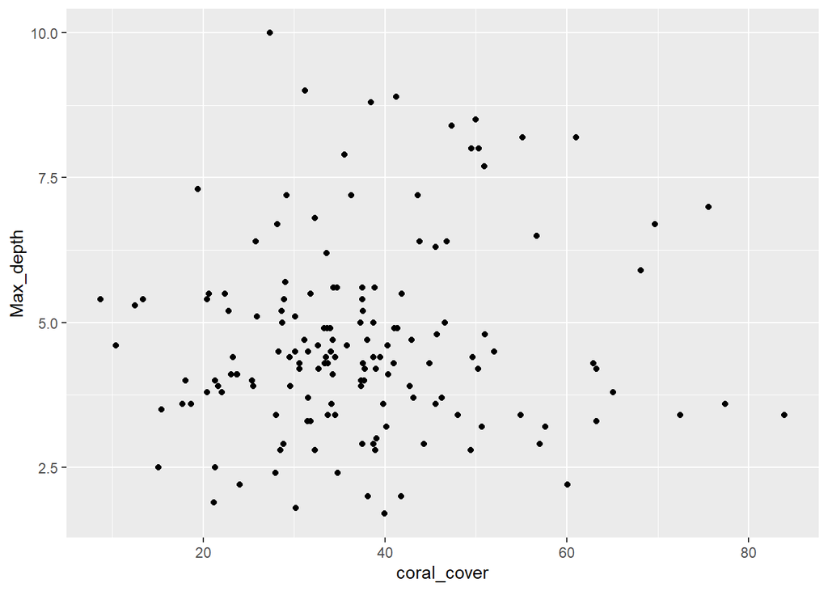

```r
# basic ggplot

ggplot(data = fish_wide,aes(x = coral_cover, y = Max_depth))+
  geom_point()
```

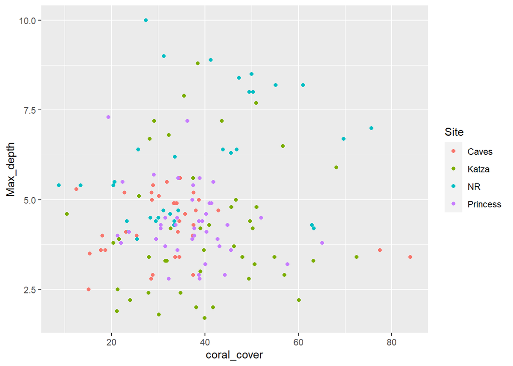

```r
# lets color the point according to the site

ggplot(data = fish_wide,aes(x = coral_cover, y = Max_depth,color = Site)) +
  geom_point()
```

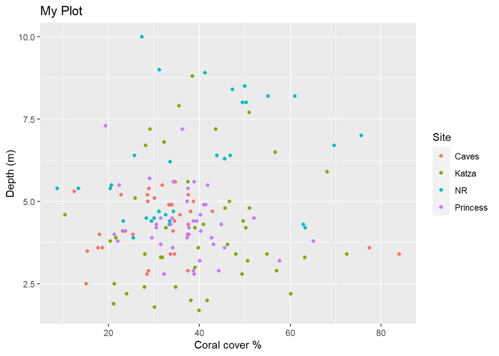

```r
# add title and axes labals

ggplot(data = fish_wide,
       aes(x = coral_cover, y = Max_depth, color = Site))+
  geom_point()+
  xlab("Coral cover %") +
  ylab("Depth (m)")+
  ggtitle("My Plot")
```

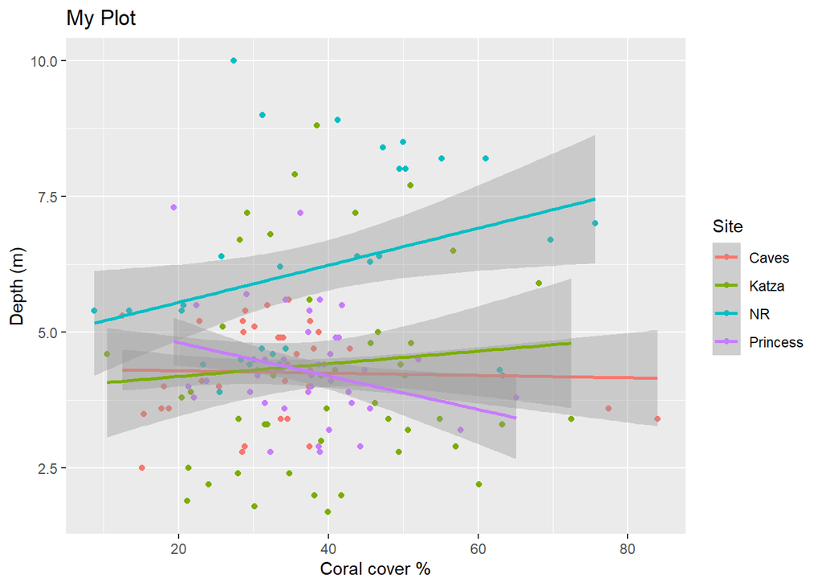

```r
# lets add simple regrassion line:

ggplot(data = fish_wide,
       aes(x = coral_cover, y = Max_depth, color = Site))+
  geom_point()+
  xlab("Coral cover %") +
  ylab("Depth (m)") +
  ggtitle("My Plot")+
  geom_smooth(method = 'lm')
```

#### lets plot the knolls size distribution

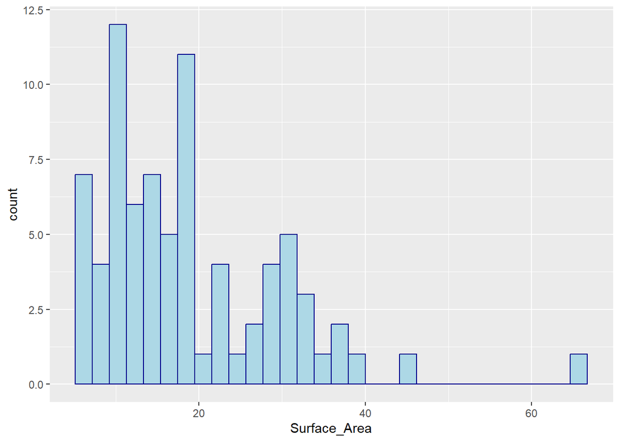

```r
# as histogram

fish_wide %>%
  filter(Year == "2018") %>%
  ggplot(aes(x= Surface_Area))+
  geom_histogram(color="darkblue", fill="lightblue")
```

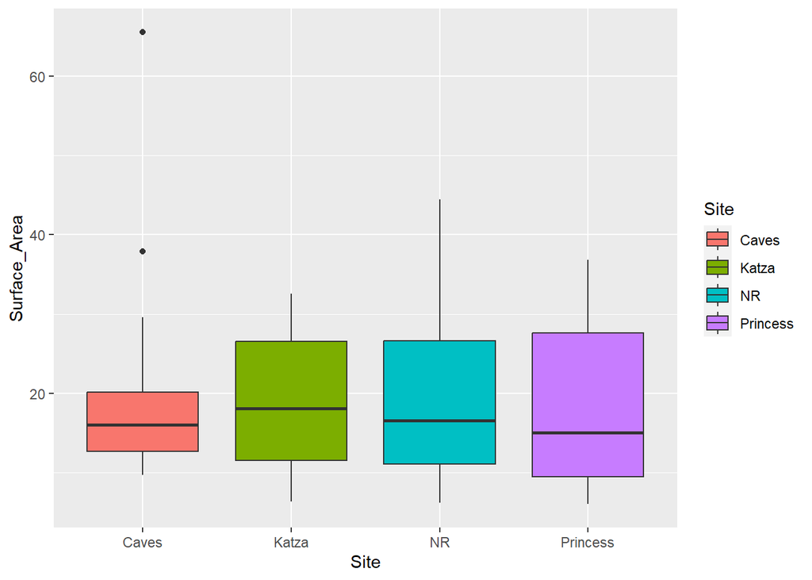

```r
# as box plot per site

fish_wide %>%
  filter(Year == "2018") %>%
  ggplot(aes(x=Site,y= Surface_Area,fill = Site))+
  geom_boxplot()
```

- note - we can use the `%>%` to first adjust our data and than plot it, without savingit first as new data.

#### let see how the coral cover change in each knoll over the years in the NR site:

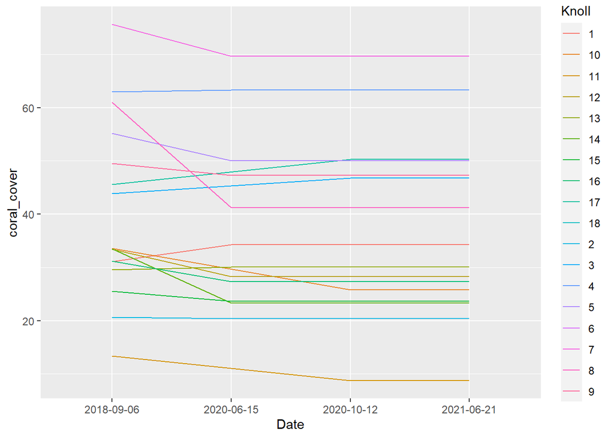

```r
fish_wide %>%
  filter(Site == "NR") %>%
  ggplot(aes(x = Date,y= coral_cover,group = Knoll,color = Knoll))+
  geom_line()
```

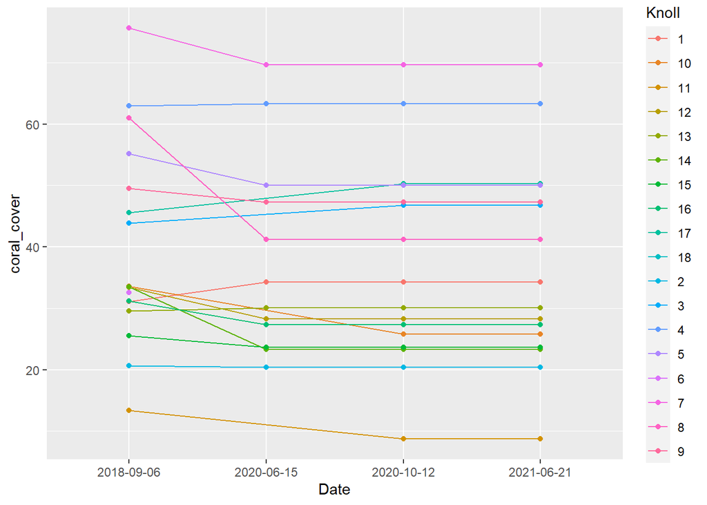

```r
# we can also add point to line plot

fish_wide %>%
  filter(Site == "NR") %>%
  ggplot(aes(x = Date,y= coral_cover,group = Knoll,color = Knoll))+
  geom_line()+
  geom_point()
```

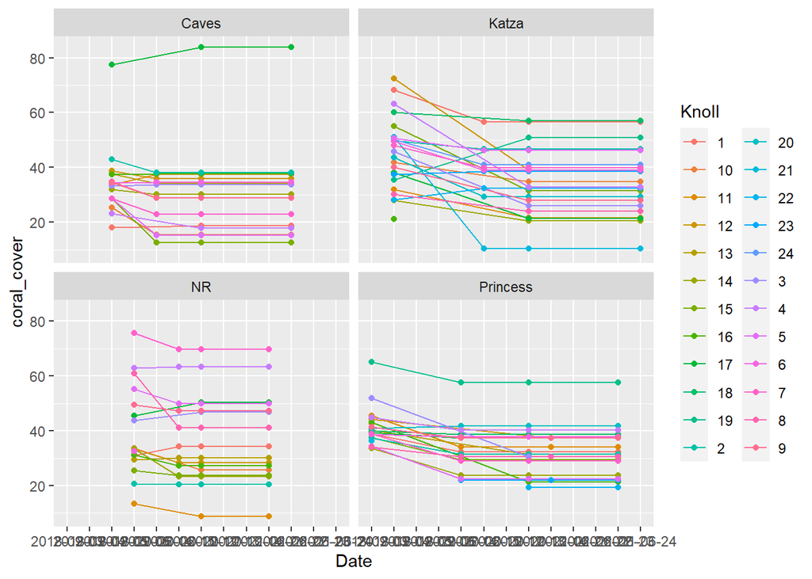

```r
# lets plot it for all sites:

  ggplot(data =fish_wide,aes(x = Date,y= coral_cover,group = Knoll,color = Knoll))+
  geom_line()+
  geom_point()+
  facet_wrap(~ Site)
```

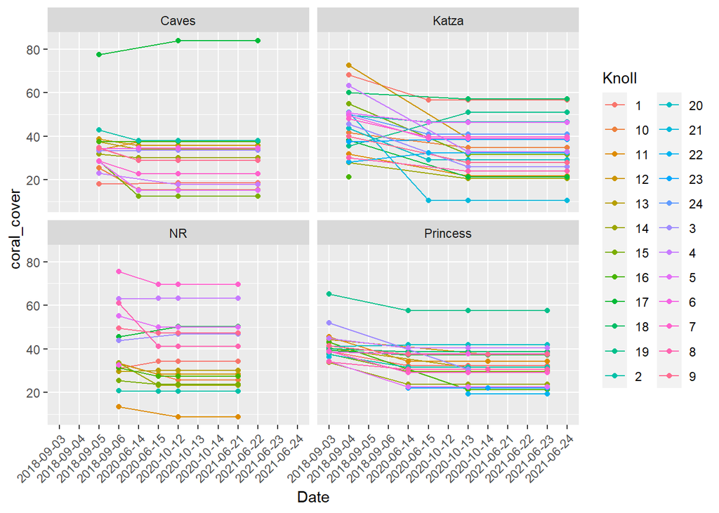

```r
# litte bit of cosmetics - lets change the angle of the dates in the x-axis

ggplot(data =fish_wide,aes(x = Date,y= coral_cover,group = Knoll,color = Knoll))+
  geom_line()+
  geom_point()+
  facet_wrap(~ Site)+
  guides(x =  guide_axis(angle = 45))
```

**The last steps are to save the plot and all our work for further work (like your MSc thesis).**

To save the plot:

[figure not shown]

another option to save your plot is using `ggsave()`

```r
ggsave("coral_cover.png")
```

this line will save the last plot you created. look at `ggsave` for more saving options.

**lets save the data as well:**

```r
write.csv(fish_wide,"fish_wide.csv")

write.csv(fish_data,"clean_fish_data.csv")
```

# 10 Getting Help

[figure not shown]

Good programming means working on your Google search skills. Since R is so widely used by people at all levels - chances are someone had already encountered your issue, asked about it, and received a lot of useful answers. A good programmer knows how to copy and paste adapt existing code.

# Class/Homework exersice

Plot the relationship between the number of individuals to the number of species for the different samples in your data.

This exercise will help you understand your data better and detect trends or problems in your data at early stage.

**Try to write the script yourself before checking out the example script found at the end of this documented**

# For next class:

**Have your data organized in wide format and ready for work!**

- make sure you can upload your data to r studio
- make sure each row is one sample
- arrange all the metadata columns on the right and all the species afterwards (like in `fish_wide`)
- Use the function `class` or `str` to make sure that numeric columns are indeed numeric. (if not use `as.numeric()` to convert them)
- make sure you don’t have summary row at the bottom or top
- avoid Hebrew text, especially as columns names

#### example script

plotting the relationship between species and individuals number:

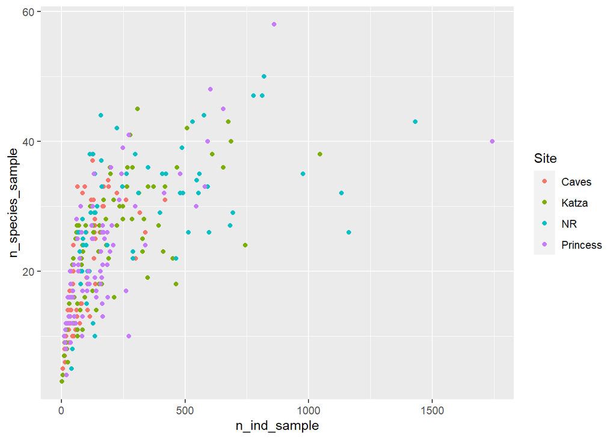

```r
ggplot(data=fish_wide,
       aes(x=n_ind_sample,
           y=n_species_sample,
           color = Site))+
  geom_point()
```

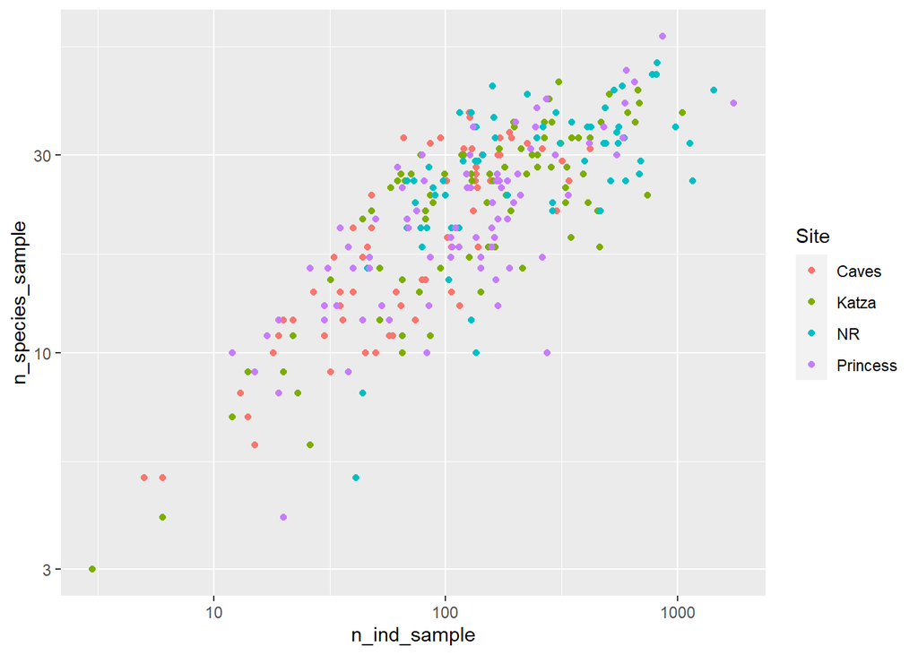

```r
# it will be easier to look at this at log scale:

ggplot(data=fish_wide,
       aes(x=n_ind_sample,
           y=n_species_sample,
           color = Site))+
  geom_point()+
  scale_x_log10()+
  scale_y_log10()
```

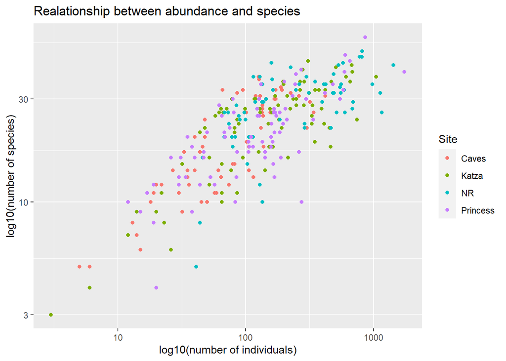

```r
# add some labels:

ggplot(data=fish_wide,
       aes(x=n_ind_sample,
           y=n_species_sample,
           color = Site))+
  geom_point()+
  scale_x_log10()+
  scale_y_log10()+
  xlab("log10(number of individuals)")+
  ylab("log10(number of species)")+
  ggtitle("Realationship between abundance and species")
```

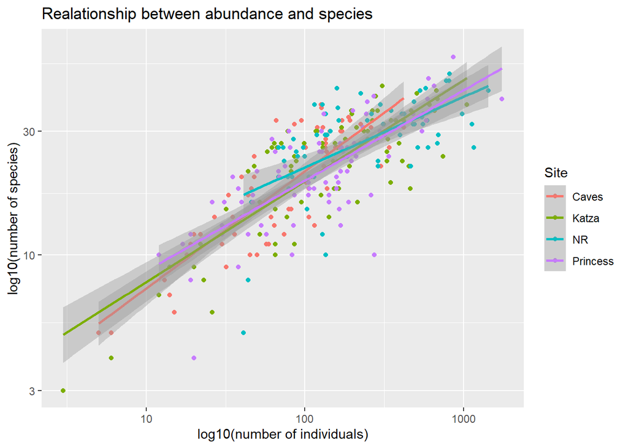

```r
# add regrassion lines:

ggplot(data=fish_wide,
       aes(x=n_ind_sample,
           y=n_species_sample,
           color = Site))+
  geom_point()+
  scale_x_log10()+
  scale_y_log10()+
  xlab("log10(number of individuals)")+
  ylab("log10(number of species)")+
  ggtitle("Realationship between abundance and species")+
  geom_smooth(method = "lm")
```